# Rmarkdown_assignment2

## Molecular descriptors and dataset editing

Certain columns from the query subset are extracted and renamed to use them at a further point in the process. The chosen physicochemical properties are retrieved from the rcdk github for the selected parsed SMILES. These results are stored in ‘descs’ as a dataframe, to which the boilingpoints from the wikidata query are added. From this, two subsets are made: a training-set and a test-set. The splitting of the data into a training- and test-set can be done in any matter, based on the random distribution seen above. The way the data is split does however affect the error calculated further on.

```r
bps_measured = subset_query[,3]; # Renaming column 3 of the subsetted query data to further use this column
smiles = subset_query[,6]; # Renaming column 6 of the subsetted query data to further use this column

mols = parse.smiles(subset_query[,6]); # Parses the SMILES given
# Selection of physicochemical properties requested
descNames <- c( 'org.openscience.cdk.qsar.descriptors.molecular.WienerNumbersDescriptor',
                'org.openscience.cdk.qsar.descriptors.molecular.APolDescriptor',
                'org.openscience.cdk.qsar.descriptors.molecular.CarbonTypesDescriptor',
                'org.openscience.cdk.qsar.descriptors.molecular.AtomCountDescriptor'
                );
descs = eval.desc(mols, descNames); # Request the properties for the selected SMILES

desc_dataset = cbind(descs, bps_measured) # Binding the molecular descriptors with boilingpoints
desc_test = desc_dataset[1:20,]; # Establishing a test dataset
desc_train = desc_dataset[21:114,] # Establishing a train dataset
```

# The Model

## Construction of the Model and training

A Partial Least Squares Regression model is constructed using the PLS package to investigate whether the boiling points of the aliphatic alkanes can be predicted. The model is validated using the Leave-One-Out validation method from the PLS package. The RMSEP (Root Mean Square Error of Prediction) plot show the expected error for each number of components used in the model. Based on this graph, the number of component used for testing will be 2. The error is more or less the same for all number of components higher than one. Using 2 will ensure the simplest model possible. The scatterplot of the model shows the distribution of the trainingset data along the regression line. The scatterplot is shown here for 2 components since this is the number of components that will be used for the test-dataset.

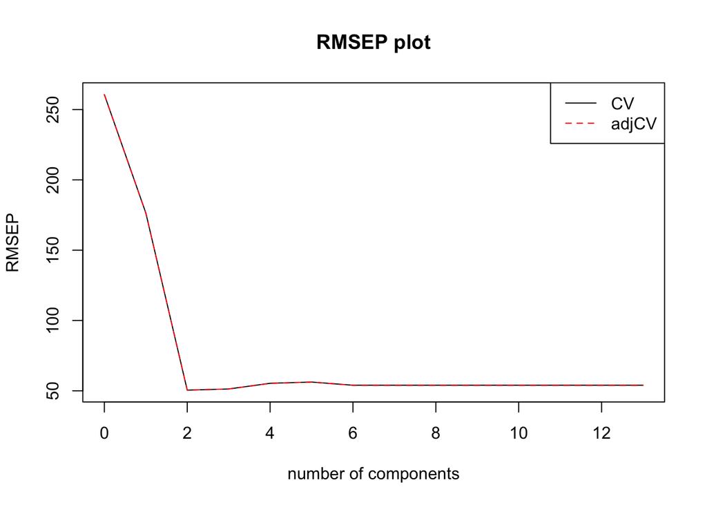

```r
PLStest = plsr(bps_measured ~ ., data = desc_train, validation = "LOO"); # Partial Least Square model
plot(RMSEP(PLStest), legendpos = "topright", main = "RMSEP plot") # Plot the error for each amount of latent variables considered
```

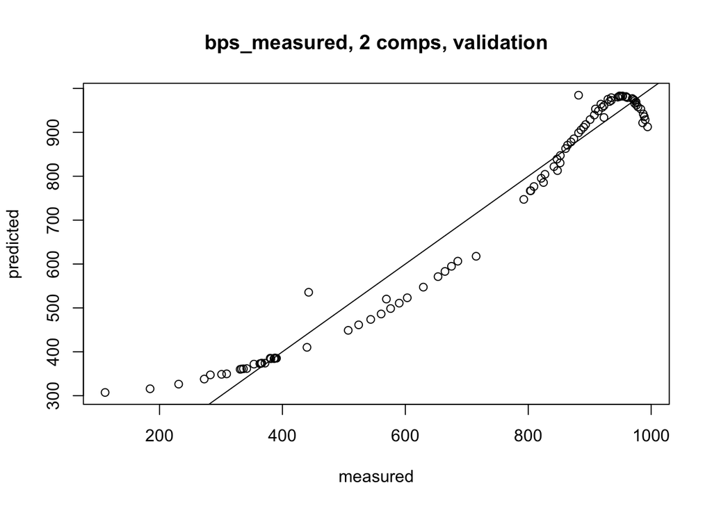

```r
plot(PLStest, ncomp = 2, line = TRUE) # Visualisation of the PLS model
```

## Testing of the model

Now that the model has been constructed, it can be tested. The predict function will use the previously constructed PLS model to try to predict boiling points based on the molecular descriptors of the data in the test dataset. The number of components used here is 2. This was found to be the simplest model while also being within a reasonable error range. The result was plotted in a scatterplot. The regression line shown here visualises the model. The RMSEP function displays again the error of the model for each number of components The fact that the error here was the lowest for 2 components confirms that this was choosen correctly.

```r
predict(PLStest, ncomp = 2, newdata = desc_test) # Prediction of boilingpoints using the test data
```

```
## , , 2 comps
##
##                                                                                                 bps_measured
## CCCCCCCCCCCCCCCCCCCCCCCCCCCCCCCCCCCCCCCCCCCCCCCCCCCCCCCCCCCCCCCCC                                   943.2857
## CCCC.CC.CC                                                                                          386.6879
## CCC.C..CC.CC                                                                                        387.2809
## CCC.C.C.C..C.C                                                                                      385.3241
## CCCCCCCCCCCCCCCCCCCCCCCCCCCCCCCCCCCCCCCCCCCCCCCCCCCCCCCCCCCCCCCCCCCCCCCCCCCCCCCCCCCCCCCCCCCCCCC     950.2805
## CCCCCCCCCCCCCCCCCCCCCCCCCCCCCCCCCCCCCCCCCCCCCCCCCCCCCCCCCCCCCCCCCCCCCCCCCCC                         976.2639
## CCCCCCCCCCCCCCCCCCCCCCCCCCCCCCCCCCCCCCCCCCCCCCCCCCC                                                 855.2700
## CCC.C.C.C..C.C.1                                                                                    385.3241
## CCCCCCCCC                                                                                           399.5186
## CCCCCCCCCCCCCCCCCCCCCCCCCCCCCCCCCCCCCCCCCCCCCCCCCCCCCCCCCCCCC                                       922.7549
## CCCCCCCCCCCCCCCCCCCCCCCCCCCCCCCCCCC                                                                 707.4196
## CCCCCCCCCCCCCCCCCCCCCCCCCCCCCCCCCCCCC                                                               728.1466
## CCCCCCCCCCCCCCCCCCCCCCCCCCCCCCCCCC                                                                  696.8488
## CCCC.C.CCC                                                                                          386.0625
## CC.C.CCCC.CCCCC.CCCC.C.C.C.C                                                                        533.2053
## CCCCCCCCCCCCCCCCCCCCCCCCCCCCCCCCCCCC                                                                717.8535
## CCCCCCCCCCCCCCCCCCCCCCCCCCCCCCCCCCCCCC                                                              738.2949
## CCCCCCCCCCCCCCCCCCCCCCCCCCCCCCCCCCCCCCCCCCCCCCCCCCCCCCCCCCCCCCCCCCCCCCC                             966.3746
## CCC.CC.C.C.C                                                                                        385.9739
## CCCC.C..C.CC                                                                                        386.0419
```

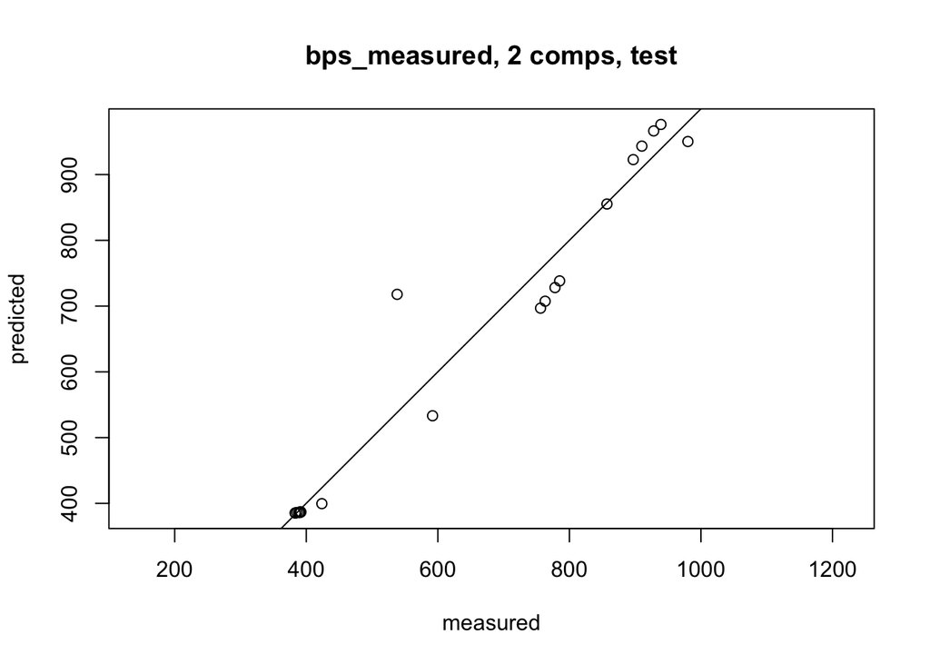

```r
predplot(PLStest, ncomp = 2, newdata = desc_test, asp = 1, line = TRUE) # The test data is plotted
```

```r
RMSEP(PLStest, newdata = desc_test) # RMSEP for each of the possible components for the test dataset
```

```
## (Intercept)      1 comps      2 comps      3 comps      4 comps
##      239.66       161.03        51.59        53.67        55.05
##     5 comps      6 comps      7 comps      8 comps      9 comps
##       55.54        53.91        53.91        53.91        53.91
##    10 comps     11 comps     12 comps     13 comps
##       53.91        53.91        53.91        53.91
```